# Work Based Learning Assignments

**Author:** Jane Daisy Adhiambo  
**Objective:** learning computer science practical from Cordio East Africa  
**Mentors**: James Mbugua and Nimrod Ishmael

## Mangrove Forest Degradation Analysis Based on Stump Count

#### Breakdown of the Script:

*The R script processes data from an Excel file (Mangrove_sample_data.xlsx) to analyze and visualize mangrove forest degradation based on the number of stumps recorded. It first loads necessary libraries (readxl, openxlsx, ggplot2, dplyr) for data manipulation and visualization. The script then groups the data by block names and forest types, summarizing the total number of stumps in each category. Two bar charts are generated: one displaying stump counts per block and another showing stump counts per forest type, helping to identify areas with higher degradation levels. The visualization uses a minimal theme with clear labels to enhance readability.*

##### Libraries

```r
library(readxl)
library(ggplot2)
library(openxlsx)
library(dplyr)
```

##### Summarize Stumps Per Block

```r
data_excel <- "./Daisy_Challenge2/Mangrove_sample_data.xlsx"
df <- read.xlsx(data_excel, sheet = 1)


df_summary <- df %>%
  group_by(Block_Names) %>%
  summarise(Total_Stumps = sum(Stumps, na.rm = TRUE))

print(df_summary)
```

```
## # A tibble: 8 × 2
##   Block_Names Total_Stumps
##   <chr>              <dbl>
## 1 Kiunga                 6
## 2 Kiwayu                20
## 3 Mkokoni               18
## 4 Pethali                9
## 5 Rewa                   5
## 6 Rubu                  13
## 7 Siyu                   9
## 8 Uvondo                70
```

##### bar graph presentation

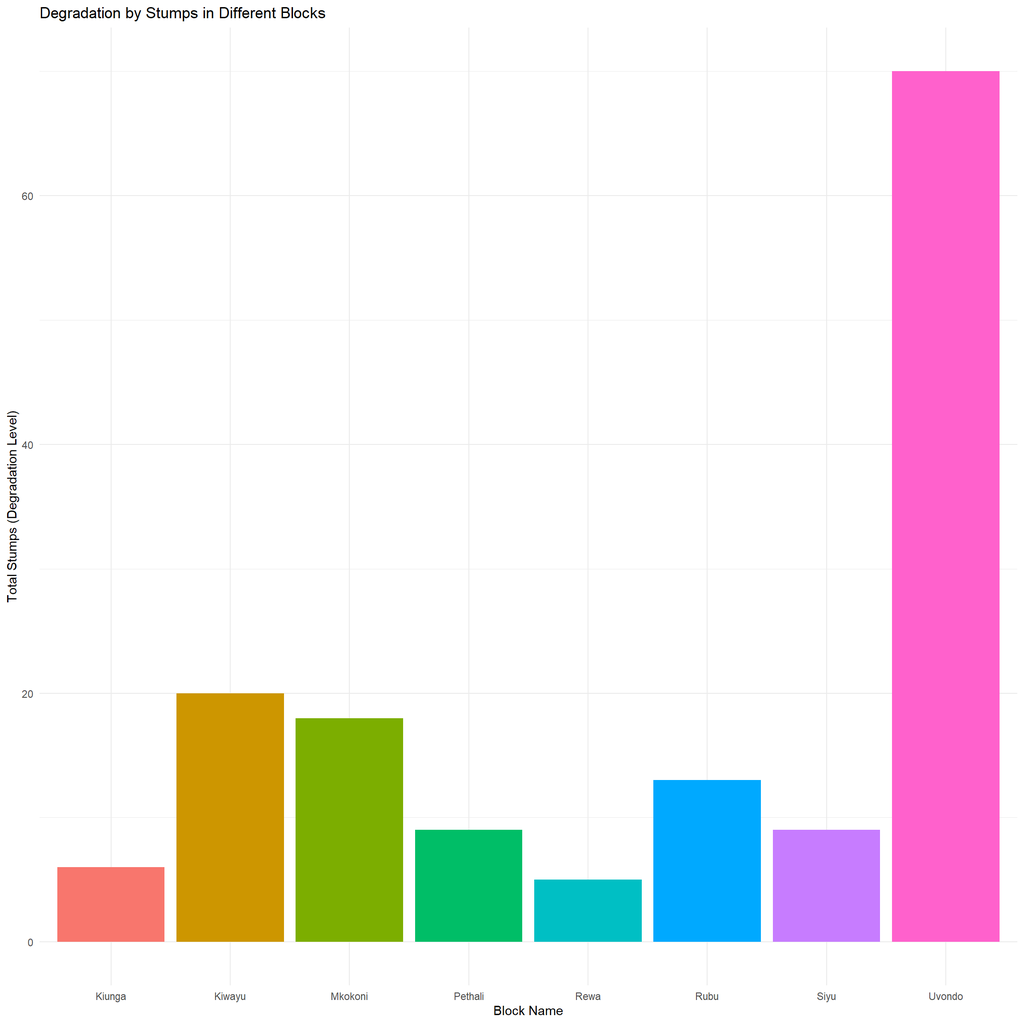

```r
ggplot(df_summary, aes(x = Block_Names, y = Total_Stumps, fill = Block_Names)) +
  geom_bar(stat = "identity") + #use actual values from df_summary
  labs(title = "Degradation by Stumps in Different Blocks",
       x = "Block Name",
       y = "Total Stumps (Degradation Level)") +
  theme_minimal() +
  theme(legend.position = "none")  # Remove legend since colors just help differentiate
```

## Degradation by Stumps in Different Forest Types

```r
data_excelsheet <- "./Daisy_Challenge2/Mangrove_sample_data.xlsx"
df1 <- read.xlsx(data_excelsheet, sheet = 1)


df_summary1 <- df1 %>%
  group_by(Forest_Typ) %>%
  summarise(Total_Stumps = sum(Stumps, na.rm = TRUE))

print(df_summary1)
```

```
## # A tibble: 10 × 2
##    Forest_Typ                            Total_Stumps
##    <chr>                                        <dbl>
##  1 A. marina                                        4
##  2 A. marina, C. Tagal                              9
##  3 C. tagal                                        11
##  4 R. mucronata                                    88
##  5 R. mucronata, A. marina                          8
##  6 R. mucronata, C. tagal                           4
##  7 R. mucronata, C. tagal, B. gymnorhiza            0
##  8 R. mucronata, S. Alba                            5
##  9 S. Alba                                         20
## 10 S. Alba and A. marina                            1
```

##### bar graph presentation

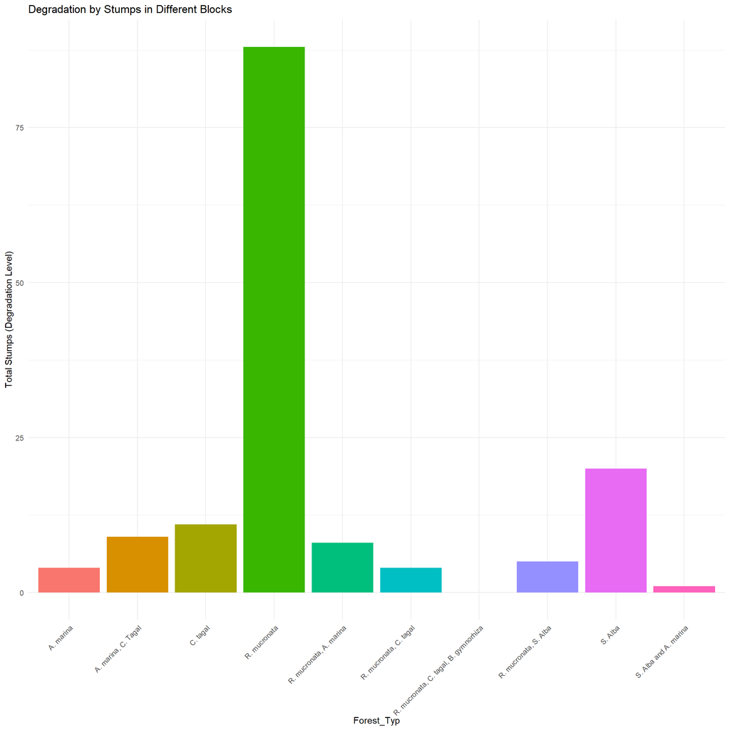

```r
ggplot(df_summary1, aes(x = Forest_Typ, y = Total_Stumps, fill = Forest_Typ)) +
  geom_bar(stat = "identity") + #use actual values from df_summary1
  labs(title = "Degradation by Stumps in Different Blocks",
       x = "Forest_Typ",
       y = "Total Stumps (Degradation Level)") +
  theme_minimal() +
  theme(axis.text.x = element_text(angle = 45, hjust = 1)) + # Rotate labels 45 degrees
  theme(legend.position = "none")  # Remove legend since colors just help differentiate
```

## Gender-Based Attendance Analysis in Kilifi Central and Bofa

*This R script visualizes gender-based attendance at two locations: Kilifi Central and Bofa. Using ggplot2, the script generates two bar charts representing the number of male and female attendees at each site. The data is structured in a simple dataframe, grouping attendees by gender. The Kilifi Central chart shows 18 male and 12 female attendees, while the Bofa chart displays 29 male and 12 female attendees. The bars are color-coded with blue for males and pink for females for easy differentiation. The visualization helps compare attendance patterns between the two locations, highlighting gender distribution.*

```r
library(ggplot2)
```

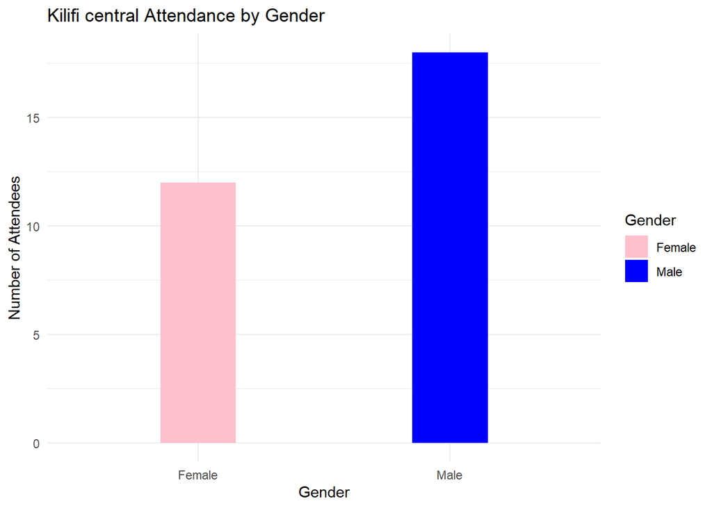

```r
# Sample data: Number of attendees by gender
attendance_data <- data.frame(
  Gender = c("Male", "Female"),
  Count = c(18, 12)  # Replace with your actual numbers
)
ggplot(attendance_data, aes(x = Gender, y = Count, fill = Gender)) +
  geom_bar(stat = "identity",width = 0.3) +
  labs(title = "Kilifi central Attendance by Gender", x = "Gender", y = "Number of Attendees") +
  theme_minimal() +
  scale_fill_manual(values = c("Male" = "blue", "Female" = "pink"))
```

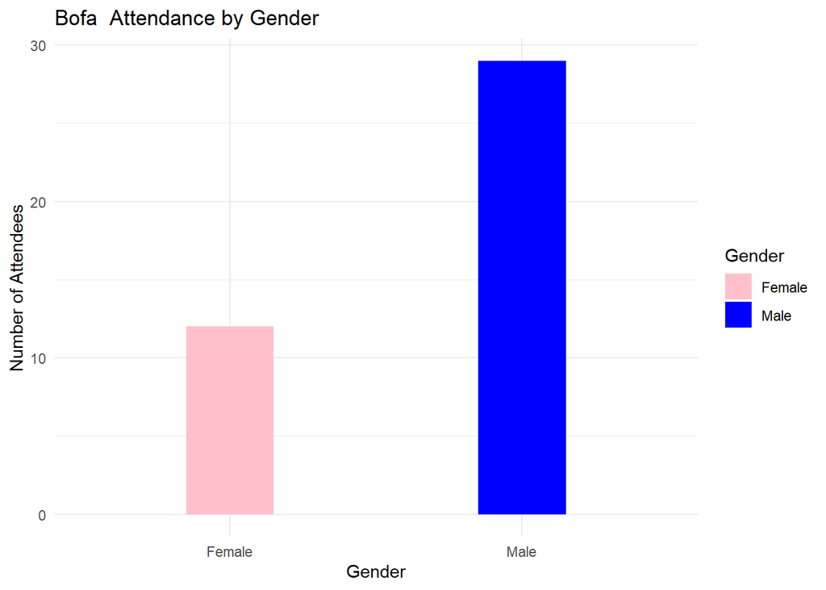

```r
# Sample data: Number of attendees by gender
attendance_data <- data.frame(
  Gender = c("Male", "Female"),
  Count = c(29, 12)  # Replace with your actual numbers
)
ggplot(attendance_data, aes(x = Gender, y = Count, fill = Gender)) +
  geom_bar(stat = "identity",width = 0.3) +
  labs(title = "Bofa  Attendance by Gender", x = "Gender", y = "Number of Attendees") +
  theme_minimal() +
  scale_fill_manual(values = c("Male" = "blue", "Female" = "pink"))
```

## Mapping Mangrove Forest Distribution and Degradation in Lamu County

*This R script processes and visualizes mangrove forest data in Lamu County by converting Excel (.xlsx) data into CSV format, extracting latitude and longitude coordinates, converting them from Degrees, Minutes, Seconds (DMS) to Decimal Degrees (DD), and exporting the data as a shapefile (.shp). The script utilizes spatial libraries (sf, tmap, tmaptools) to create maps overlaying mangrove forest types onto the Lamu County boundary shapefile. The final visualization categorizes different forest types, displays their spatial distribution, and includes a compass, legend, and county label for better interpretation. The processed map is saved as an image for further analysis.*

##### libraries

```r
library(dplyr)    # Data manipulation
library(tidyr)    # Data tidying
library(stringr)  # String manipulation
library(sf) # Spatial data (Shapefile export)
library(sp)
library(readr)    # Reading data (CSV, etc.)
library(bslib)
library(openxlsx) # for the excel
library(tmap)
library (tmaptools)#additional tools for maps
```

##### changing .xlsx to csv

```r
# Correct file path
#excel_file <- "C:/Users/Cordio ea/Documents/Jane Daisy_Challenge/Mangrove_sample_data.xlsx"


excel_file<-"./Jane Daisy_Challenge/Mangrove_sample_data.xlsx"

# Read the first sheet of the Excel file
data_excel <- read.xlsx(excel_file, sheet = 1)
#data_locale <- "C:/Users/Cordio ea/Documents/Jane Daisy_Challenge/output_file.csv"
data_locale <- "./Jane Daisy_Challenge/output_file.csv"

# Save as CSV
write.csv(data_excel, data_locale, row.names = FALSE)


site_coordinates <- read.csv(data_locale)
# Display the first 5 rows of the data
head(site_coordinates, 5)
```

```
##   OBJECTID       ID  Date        Observers   Block        Site Site_ID Plot_No
## 1        1        X 42067           Hashim Pethali Shinda kasi   PET_1       4
## 2        2   PCPO 8 42067           Hashim Pethali    Chongoni   PET_2       0
## 3        4      PC9 42067 Judith and group Pethali    Chongoni   PET_4       9
## 4        5      PC3 42067 Judith and group Pethali    Chongoni   PET_5       3
## 5        6 SSSiyu A 42068   Hashim, Judith    Siyu  Siyu Jetty   SIY_1       0
##            Lat          Lon              Forest_Typ Vegetation Stumps
## 1  -2°8'31.06"  40°58'9.52"            R. mucronata         70      2
## 2 -2°12'20.74" 40°59'45.35"            R. mucronata         34      1
## 3  -2°10'1.81" 40°57'54.76" R. mucronata, A. marina         15      1
## 4  -2°8'34.87" 40°57'49.32" R. mucronata, A. marina         55      0
## 5   -2°5'9.02"  41°3'17.57"                C. tagal         70      0
##   Inudation_        Status Block_Names
## 1          1 P_transect_ii     Pethali
## 2          1  P_Spot_check     Pethali
## 3          1  P_transect_i     Pethali
## 4          1 P_transect_ii     Pethali
## 5          3  S_spot_check        Siyu
```

```r
coordinate_extracted <- site_coordinates %>%
  mutate(
    # Extract Degrees, Minutes, and Seconds for Latitude
    Lat_degrees = as.numeric(str_extract(Lat, "^\\-?\\d+(?=°)")),  # Extract degrees (allow for negative)
    Lat_minutes = as.numeric(str_extract(Lat, "(?<=°)\\d+(?=')")),  # Extract minutes (after degree symbol)
   Lat_seconds = as.numeric(str_extract(Lat, "(?<=')\\d+(\\.\\d+)?(?=\")")),  # Extract seconds with decimal (after minutes)

    # Extract Degrees, Minutes, and Seconds for Longitude
    Long_degrees = as.numeric(str_extract(Lon, "^\\-?\\d+(?=°)")),  # Extract degrees (allow for negative)
    Long_minutes = as.numeric(str_extract(Lon, "(?<=°)\\d+(?=')")),  # Extract minutes (after degree symbol)
       Long_seconds = as.numeric(str_extract(Lon, "(?<=')\\d+(\\.\\d+)?(?=\")"))  # Extract seconds with decimal (after minutes)
  )

# Check the first few rows of the data after extraction
head(coordinate_extracted, 5)
```

```
##   OBJECTID       ID  Date        Observers   Block        Site Site_ID Plot_No
## 1        1        X 42067           Hashim Pethali Shinda kasi   PET_1       4
## 2        2   PCPO 8 42067           Hashim Pethali    Chongoni   PET_2       0
## 3        4      PC9 42067 Judith and group Pethali    Chongoni   PET_4       9
## 4        5      PC3 42067 Judith and group Pethali    Chongoni   PET_5       3
## 5        6 SSSiyu A 42068   Hashim, Judith    Siyu  Siyu Jetty   SIY_1       0
##            Lat          Lon              Forest_Typ Vegetation Stumps
## 1  -2°8'31.06"  40°58'9.52"            R. mucronata         70      2
## 2 -2°12'20.74" 40°59'45.35"            R. mucronata         34      1
## 3  -2°10'1.81" 40°57'54.76" R. mucronata, A. marina         15      1
## 4  -2°8'34.87" 40°57'49.32" R. mucronata, A. marina         55      0
## 5   -2°5'9.02"  41°3'17.57"                C. tagal         70      0
##   Inudation_        Status Block_Names Lat_degrees Lat_minutes Lat_seconds
## 1          1 P_transect_ii     Pethali          -2           8       31.06
## 2          1  P_Spot_check     Pethali          -2          12       20.74
## 3          1  P_transect_i     Pethali          -2          10        1.81
## 4          1 P_transect_ii     Pethali          -2           8       34.87
## 5          3  S_spot_check        Siyu          -2           5        9.02
##   Long_degrees Long_minutes Long_seconds
## 1           40           58         9.52
## 2           40           59        45.35
## 3           40           57        54.76
## 4           40           57        49.32
## 5           41            3        17.57
```

```r
coordinate_cleaned <- coordinate_extracted %>%
  mutate(
    # Clean Latitude and Longitude Degrees, Minutes, and Seconds
    Lat_degrees = as.numeric(Lat_degrees),  # Ensure degrees are numeric
    Lat_minutes = as.numeric(Lat_minutes),  # Ensure minutes are numeric
    Lat_seconds = as.numeric(Lat_seconds),  # Ensure seconds are numeric

    Long_degrees = as.numeric(Long_degrees),  # Ensure degrees are numeric
    Long_minutes = as.numeric(Long_minutes),  # Ensure minutes are numeric
    Long_seconds = as.numeric(Long_seconds),  # Ensure seconds are numeric

    # Adjust for negative values (if applicable)
    Lat_degrees = if_else(str_detect(Lat, "S"), -Lat_degrees, Lat_degrees),  # Handle Southern Hemisphere
    Long_degrees = if_else(str_detect(Lon, "W"), -Long_degrees, Long_degrees),  # Handle Western Hemisphere

    # Convert Latitude and Longitude to Decimal Degrees (DD)
    Lat_decimal = Lat_degrees + (Lat_minutes / 60) + (Lat_seconds / 3600),
    Long_decimal = Long_degrees + (Long_minutes / 60) + (Long_seconds / 3600)
  )

# Check the first few rows after cleaning and conversion
#head(coordinate_cleaned, 5)
# Save as CSV
write.csv(coordinate_cleaned, data_locale, row.names = FALSE)
DD_coordinates <- read.csv(data_locale)

# Display the first 5 rows of the data
head(DD_coordinates, 5)
```

```
##   OBJECTID       ID  Date        Observers   Block        Site Site_ID Plot_No
## 1        1        X 42067           Hashim Pethali Shinda kasi   PET_1       4
## 2        2   PCPO 8 42067           Hashim Pethali    Chongoni   PET_2       0
## 3        4      PC9 42067 Judith and group Pethali    Chongoni   PET_4       9
## 4        5      PC3 42067 Judith and group Pethali    Chongoni   PET_5       3
## 5        6 SSSiyu A 42068   Hashim, Judith    Siyu  Siyu Jetty   SIY_1       0
##            Lat          Lon              Forest_Typ Vegetation Stumps
## 1  -2°8'31.06"  40°58'9.52"            R. mucronata         70      2
## 2 -2°12'20.74" 40°59'45.35"            R. mucronata         34      1
## 3  -2°10'1.81" 40°57'54.76" R. mucronata, A. marina         15      1
## 4  -2°8'34.87" 40°57'49.32" R. mucronata, A. marina         55      0
## 5   -2°5'9.02"  41°3'17.57"                C. tagal         70      0
##   Inudation_        Status Block_Names Lat_degrees Lat_minutes Lat_seconds
## 1          1 P_transect_ii     Pethali          -2           8       31.06
## 2          1  P_Spot_check     Pethali          -2          12       20.74
## 3          1  P_transect_i     Pethali          -2          10        1.81
## 4          1 P_transect_ii     Pethali          -2           8       34.87
## 5          3  S_spot_check        Siyu          -2           5        9.02
##   Long_degrees Long_minutes Long_seconds Lat_decimal Long_decimal
## 1           40           58         9.52   -1.858039     40.96931
## 2           40           59        45.35   -1.794239     40.99593
## 3           40           57        54.76   -1.832831     40.96521
## 4           40           57        49.32   -1.856981     40.96370
## 5           41            3        17.57   -1.914161     41.05488
```

```r
# Convert to sf object (Spatial Data Frame)
sf_data <- st_as_sf(DD_coordinates, coords = c("Long_decimal", "Lat_decimal"), crs = 4326)


# Check the structure of the spatial data
print(sf_data)
```

```
## Simple feature collection with 75 features and 22 fields
## Geometry type: POINT
## Dimension:     XY
## Bounding box:  xmin: 40.9637 ymin: -1.995569 xmax: 41.49423 ymax: -0.007111111
## Geodetic CRS:  WGS 84
## First 10 features:
##    OBJECTID             ID  Date         Observers   Block        Site Site_ID
## 1         1              X 42067            Hashim Pethali Shinda kasi   PET_1
## 2         2         PCPO 8 42067            Hashim Pethali    Chongoni   PET_2
## 3         4            PC9 42067  Judith and group Pethali    Chongoni   PET_4
## 4         5            PC3 42067  Judith and group Pethali    Chongoni   PET_5
## 5         6       SSSiyu A 42068    Hashim, Judith    Siyu  Siyu Jetty   SIY_1
## 6         7       SSSiyu C 42068            Judith    Siyu        Siyu   SIY_2
## 7         8 SSSpot Check 1 42068 Judith and Hashim    Siyu   Siyu Bori   SIY_3
## 8         9 SSSpot Check 4 42068            Hashim    Siyu   Siyu Bori   SIY_4
```

[output cut: 35 more lines]

```r
#shapefile_path <- "C:/Users/Cordio ea/Documents/Jane Daisy_Challenge/output_shapefile.shp"
shapefile_path <-"./Jane Daisy_Challenge/output_shapefile.shp"
st_write(sf_data, shapefile_path, delete_layer = TRUE)
```

```
## Deleting layer `output_shapefile' using driver `ESRI Shapefile'
## Writing layer `output_shapefile' to data source
##   `./Jane Daisy_Challenge/output_shapefile.shp' using driver `ESRI Shapefile'
## Writing 75 features with 22 fields and geometry type Point.
```

##### Steps to Create a Map with Categories

```r
# Load the shapefile
#sf_map <- st_read("shapefile_path")

# Check column names
#colnames(sf_map)

# Create the map and assign it to an object
#mangrove_map <- tm_shape(sf_map) +
 # tm_dots(col = "Vegettn", palette = "brewer.set1", title = "Vegetation Type") +
 # tm_basemap("OpenStreetMap") +
  #tm_layout(legend.outside = TRUE)

# Save the map as an image
#tmap_save(mangrove_map, filename = "C:/Users/Cordio ea/Documents/Jane Daisy_Challenge/mangrove_map.png")
```

```r
# Load the mangrove points (output_shapefile)
#sf_mangrove <- st_read("C:/Users/Cordio ea/Documents/Jane Daisy_Challenge/output_shapefile.shp")
sf_mangrove <-st_read("./Jane Daisy_Challenge/output_shapefile.shp")
# Load Lamu County shapefile
#lamu_boundary <- st_read("C:/Users/Cordio ea/Documents/Jane Daisy_Challenge/Lamu_County.shp")
lamu_boundary <- st_read("./Jane Daisy_Challenge/Lamu_County.shp")
# Ensure both layers have the same CRS
sf_mangrove <- st_transform(sf_mangrove, crs = 4326)
lamu_boundary <- st_transform(lamu_boundary, crs = 4326)

# Check column names to confirm "Forest_Typ"
print(colnames(sf_mangrove))  # Ensure "Forest_Typ" exists
```

```
##  [1] "OBJECTI"  "ID"       "Date"     "Obsrvrs"  "Block"    "Site"
##  [7] "Site_ID"  "Plot_No"  "Lat"      "Lon"      "Frst_Ty"  "Vegettn"
## [13] "Stumps"   "Inudtn_"  "Status"   "Blck_Nm"  "Lt_dgrs"  "Lt_mnts"
## [19] "Lt_scnd"  "Lng_dgr"  "Lng_mnt"  "Lng_scn"  "geometry"
```

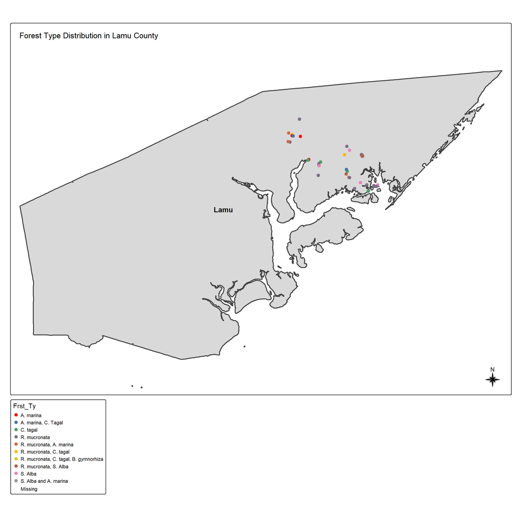

```r
# Create the overlay map
lamu_map <- tm_shape(lamu_boundary) +
  tm_borders(lwd = 2, col = "black", title = "Lamu County Boundary") +  # Lamu County Outline
  tm_text("Lamu ", size = 1.0, col = "black", fontface = "bold", xmod = -0.15, ymod = -0.05) +        # Label the County Name

  tm_shape(sf_mangrove) +
  tm_dots(col = "Frst_Ty", palette = "brewer.set1", size = 0.5, title = "Forest Type") +  # Forest Points
# Add a compass in the top-left corner
  tm_compass(position = c("right", "bottom"), type = "8star", size = 2) +
  # Add a title to the map
  tm_layout(title = "Forest Type Distribution in Lamu County",
            title.size = 1.1,
            legend.outside = TRUE)

  tm_layout(legend.outside = TRUE)

# Show the map
lamu_map
```

```r
# Save the map
#tmap_save(lamu_map, filename = "C:/Users/Cordio ea/Documents/Jane Daisy_Challenge/lamu_mangrove_map.png")
tmap_save(lamu_map, filename = "./Jane Daisy_Challenge/lamu_mangrove_map.png")
#
#
```

## Processing and Analyzing Sea Surface Temperature (SST) Data for Spatial Mapping

*This R script processes Sea Surface Temperature (SST) data from a CSV file by converting it into a spatial format and generating a shapefile (.shp) for mapping. The script first reads the raw site data, converts latitude and longitude into a Simple Features (sf) object, and exports it as a shapefile for spatial analysis. Then, it processes SST data by transforming it into long format, renaming date columns, and converting SST values from Kelvin to Celsius. It further calculates summary statistics such as maximum, minimum, and standard deviation of SST values. Finally, the processed data is saved as a CSV file for further analysis and visualization.*

```r
library(sf)
library(sp)
library(tidyverse)
```

```r
# Read the CSV file
csv_file <- "C:/Users/Cordio ea/Documents/JaneDaisy_WorkSpace/EOData_linking/Raw_sites.csv"
data <- read.csv(csv_file)

# Convert to sf object (Simple Features)
data_sf <- st_as_sf(data, coords = c("lon", "lat"), crs = 4326)  # WGS84 CRS
```

```r
# Define output path
output_folder <- "C:/Users/Cordio ea/Documents/JaneDaisy_WorkSpace/EOData_linking/"
output_file <- paste0(output_folder, "Raw_sites.shp")

# Write the Shapefile
st_write(data_sf, output_file, delete_layer = TRUE)
```

```
## Deleting layer `Raw_sites' using driver `ESRI Shapefile'
## Writing layer `Raw_sites' to data source
##   `C:/Users/Cordio ea/Documents/JaneDaisy_WorkSpace/EOData_linking/Raw_sites.shp' using driver `ESRI Shapefile'
## Writing 132 features with 3 fields and geometry type Point.
```

```r
cat("Shapefile saved at:", output_file)
```

```
## Shapefile saved at: C:/Users/Cordio ea/Documents/JaneDaisy_WorkSpace/EOData_linking/Raw_sites.shp
```

```r
extracted_data <- read.csv("C:/Users/Cordio ea/Documents/JaneDaisy_WorkSpace/EOData_linking/SST_Extracted.csv")
colnames(extracted_data)
```

```
##   [1] "County"         "Location"       "Site"           "X16_Jan_2016"
##   [5] "X17_Jan_2016"   "X18_Jan_2016"   "X19_Jan_2016"   "X20_Jan_2016"
##   [9] "X21_Jan_2016"   "X22_Jan_2016"   "X23_Jan_2016"   "X24_Jan_2016"
##  [13] "X25_Jan_2016"   "X26_Jan_2016"   "X27_Jan_2016"   "X28_Jan_2016"
##  [17] "X29_Jan_2016"   "X30_Jan_2016"   "X31_Jan_2016"   "X1_Feb_2016"
##  [21] "X2_Feb_2016"    "X3_Feb_2016"    "X4_Feb_2016"    "X5_Feb_2016"
##  [25] "X6_Feb_2016"    "X7_Feb_2016"    "X8_Feb_2016"    "X9_Feb_2016"
##  [29] "X10_Feb_2016"   "X11_Feb_2016"   "X12_Feb_2016"   "X13_Feb_2016"
##  [33] "X14_Feb_2016"   "X15_Feb_2016"   "X16_Feb_2016"   "X17_Feb_2016"
##  [37] "X18_Feb_2016"   "X19_Feb_2016"   "X20_Feb_2016"   "X21_Feb_2016"
##  [41] "X22_Feb_2016"   "X23_Feb_2016"   "X24_Feb_2016"   "X25_Feb_2016"
##  [45] "X26_Feb_2016"   "X27_Feb_2016"   "X28_Feb_2016"   "X29_Feb_2016"
##  [49] "X1_March_2016"  "X2_March_2016"  "X3_March_2016"  "X4_March_2016"
##  [53] "X5_March_2016"  "X6_March_2016"  "X7_March_2016"  "X8_March_2016"
##  [57] "X9_March_2016"  "X10_March_2016" "X11_March_2016" "X12_March_2016"
```

[output cut: 74 more lines]

##### Converting SST to long format

```r
extracted_data_long <- extracted_data %>%
  pivot_longer(
    cols = starts_with("X"),  # Select all columns starting with "X" (date columns)
    names_to = "Date",
    values_to = "SST"
  )
extracted_data_long <- extracted_data_long %>%
  mutate(Date = gsub("^X", "", Date)) %>%  # Remove "X"
  mutate(Date = as.Date(Date, format="%d_%b_%Y"))  # Convert to Date format

head(extracted_data_long)
```

```
## # A tibble: 6 × 5
##   County        Location Site        Date         SST
##   <chr>         <chr>    <chr>       <date>     <dbl>
## 1 Kilifi county Kanamai  Jumba Ruins 2016-01-16  302.
## 2 Kilifi county Kanamai  Jumba Ruins 2016-01-17  302.
## 3 Kilifi county Kanamai  Jumba Ruins 2016-01-18  302.
## 4 Kilifi county Kanamai  Jumba Ruins 2016-01-19  302.
## 5 Kilifi county Kanamai  Jumba Ruins 2016-01-20  302.
## 6 Kilifi county Kanamai  Jumba Ruins 2016-01-21  302.
```

```r
# Convert SST column to numeric
extracted_data_long$SST <- as.numeric(extracted_data_long$SST)

# Convert from Kelvin to Celsius using SST column
extracted_data_long <- extracted_data_long %>%
  mutate(SST_Celsius = SST - 273.15)

# Compute max, min, and standard deviation for SST in Celsius
max_temp_Celsius <- max(extracted_data_long$SST_Celsius, na.rm = TRUE)
min_temp_Celsius <- min(extracted_data_long$SST_Celsius, na.rm = TRUE)
std_dev_temp_Celsius <- sd(extracted_data_long$SST_Celsius, na.rm = TRUE)

# Add computed values as new columns in Celsius
extracted_data_long <- extracted_data_long %>%
  mutate(
    max_temp = max_temp_Celsius,   # Now in Celsius
    min_temp = min_temp_Celsius,
    std_dev_temp = std_dev_temp_Celsius  # Now in Celsius
  )

# Save the processed dataset to CSV
write.csv(extracted_data_long, "C:/Users/Cordio ea/Documents/JaneDaisy_WorkSpace/EOData_linking/SST_Processed.csv", row.names = FALSE)

# Print a short summary
head(extracted_data_long)
```

```
## # A tibble: 6 × 9
##   County        Location Site     Date         SST SST_Celsius max_temp min_temp
##   <chr>         <chr>    <chr>    <date>     <dbl>       <dbl>    <dbl>    <dbl>
## 1 Kilifi county Kanamai  Jumba R… 2016-01-16  302.        29.2     31.4     25.6
## 2 Kilifi county Kanamai  Jumba R… 2016-01-17  302.        29.1     31.4     25.6
## 3 Kilifi county Kanamai  Jumba R… 2016-01-18  302.        29.1     31.4     25.6
## 4 Kilifi county Kanamai  Jumba R… 2016-01-19  302.        29.1     31.4     25.6
## 5 Kilifi county Kanamai  Jumba R… 2016-01-20  302.        29.0     31.4     25.6
## 6 Kilifi county Kanamai  Jumba R… 2016-01-21  302.        29.1     31.4     25.6
## # ℹ 1 more variable: std_dev_temp <dbl>
```

```r
View(extracted_data_long)
```

## Summary statistics and histograms for WLR and SLA_Interp

```r
library(ggplot2)
library(dplyr)
library(moments)  # For kurtosis calculation
library(readr)    # For reading CSV files
```

```r
df <- read_csv("C:/Users/Cordio ea/Documents/Jane Daisy_Challenge/Raw_Ke_Transects_rates_sla.csv")
str(df)  # Check column names and types
```

```
## spc_tbl_ [14,959 × 20] (S3: spec_tbl_df/tbl_df/tbl/data.frame)
##  $ FID       : num [1:14959] 0 1 2 3 4 5 6 7 8 9 ...
##  $ Zone      : chr [1:14959] "Manda_TanaRiver" "Manda_TanaRiver" "Manda_TanaRiver" "Manda_TanaRiver" ...
##  $ Longitude : num [1:14959] 40.8 40.8 40.8 40.8 40.8 ...
##  $ Latitude  : num [1:14959] -2.35 -2.35 -2.35 -2.35 -2.35 ...
##  $ Azimuth   : num [1:14959] 214 214 214 214 214 ...
##  $ TCD       : num [1:14959] 0 25 50 75 100 125 150 175 200 225 ...
##  $ SHAPE_Leng: num [1:14959] 2430 2430 2432 2435 2705 ...
##  $ SCE       : num [1:14959] 24 21.6 20.2 20.1 286.8 ...
##  $ NSM       : num [1:14959] -1.69 -1.72 -1.8 -2.02 -2.38 -2.88 -3.73 -4.65 -5.79 -6.32 ...
##  $ EPR       : num [1:14959] -0.07 -0.07 -0.07 -0.08 -0.1 -0.12 -0.16 -0.19 -0.24 -0.26 ...
##  $ EPRunc    : num [1:14959] 0.59 0.59 0.59 0.59 0.59 0.59 0.59 0.59 0.59 0.59 ...
##  $ LRR       : num [1:14959] -0.24 -0.23 -0.22 -0.2 1.02 0.98 0.95 0.92 0.88 0.85 ...
##  $ LR2       : num [1:14959] 0.07 0.08 0.08 0.05 0.02 0.02 0.02 0.02 0.02 0.02 ...
##  $ LSE       : num [1:14959] 6.79 6.11 5.76 6.21 56.73 ...
##  $ LCI90     : num [1:14959] 0.32 0.29 0.27 0.3 2.7 2.64 2.56 2.47 2.38 2.28 ...
##  $ WLR       : num [1:14959] -0.163 -0.152 -0.149 -0.134 0.7 ...
##  $ WR2       : num [1:14959] 0.07 0.08 0.08 0.05 0.02 0.02 0.02 0.02 0.02 0.02 ...
##  $ WSE       : num [1:14959] 0.68 0.61 0.58 0.62 5.67 5.55 5.39 5.2 5.01 4.8 ...
##  $ WCI90     : num [1:14959] 0.32 0.29 0.27 0.3 2.7 2.64 2.56 2.47 2.38 2.28 ...
##  $ SLA_Interp: num [1:14959] 1.1 1.1 1.1 1.1 1.09 ...
##  - attr(*, "spec")=
##   .. cols(
##   ..   FID = col_double(),
##   ..   Zone = col_character(),
##   ..   Longitude = col_double(),
##   ..   Latitude = col_double(),
##   ..   Azimuth = col_double(),
##   ..   TCD = col_double(),
##   ..   SHAPE_Leng = col_double(),
##   ..   SCE = col_double(),
##   ..   NSM = col_double(),
##   ..   EPR = col_double(),
##   ..   EPRunc = col_double(),
##   ..   LRR = col_double(),
##   ..   LR2 = col_double(),
##   ..   LSE = col_double(),
##   ..   LCI90 = col_double(),
##   ..   WLR = col_double(),
##   ..   WR2 = col_double(),
##   ..   WSE = col_double(),
##   ..   WCI90 = col_double(),
##   ..   SLA_Interp = col_double()
##   .. )
##  - attr(*, "problems")=<externalptr>
```

```r
summary(df)  # Quick summary of numerical values
```

```
##       FID            Zone             Longitude        Latitude
##  Min.   :    0   Length:14959       Min.   :39.22   Min.   :-4.689
##  1st Qu.: 3740   Class :character   1st Qu.:39.66   1st Qu.:-4.153
##  Median : 7479   Mode  :character   Median :40.01   Median :-3.380
##  Mean   : 7479                      Mean   :40.01   Mean   :-3.469
##  3rd Qu.:11218                      3rd Qu.:40.24   3rd Qu.:-2.740
##  Max.   :14958                      Max.   :40.84   Max.   :-2.350
##     Azimuth            TCD           SHAPE_Leng        SCE
##  Min.   :  0.03   Min.   :     0   Min.   :1707   Min.   :   0.00
##  1st Qu.:281.60   1st Qu.: 93488   1st Qu.:2456   1st Qu.:  15.79
##  Median :295.30   Median :187175   Median :2508   Median :  33.15
##  Mean   :279.34   Mean   :187843   Mean   :2537   Mean   :  90.09
##  3rd Qu.:317.86   3rd Qu.:282938   3rd Qu.:2548   3rd Qu.:  94.29
##  Max.   :359.99   Max.   :376425   Max.   :7965   Max.   :2889.55
##       NSM                EPR                EPRunc            LRR
##  Min.   :-644.660   Min.   :-104.4000   Min.   :0.0000   Min.   :-92.7500
##  1st Qu.:  -3.765   1st Qu.:  -0.1600   1st Qu.:0.5900   1st Qu.: -0.2000
##  Median :   1.670   Median :   0.0700   Median :0.5900   Median :  0.0100
##  Mean   :  10.704   Mean   :   0.4548   Mean   :0.5969   Mean   :  0.2358
##  3rd Qu.:  11.525   3rd Qu.:   0.4800   3rd Qu.:0.5900   3rd Qu.:  0.3300
##  Max.   :1027.850   Max.   : 100.1500   Max.   :7.0700   Max.   : 64.6000
##       LR2              LSE             LCI90              WLR
##  Min.   :0.0000   Min.   :  0.00   Min.   :  0.000   Min.   :-60.88637
##  1st Qu.:0.0100   1st Qu.:  4.01   1st Qu.:  0.190   1st Qu.: -0.13754
##  Median :0.0700   Median :  7.73   Median :  0.370   Median :  0.00655
##  Mean   :0.1318   Mean   : 23.03   Mean   :  1.186   Mean   :  0.16109
##  3rd Qu.:0.1900   3rd Qu.: 23.06   3rd Qu.:  1.110   3rd Qu.:  0.22587
##  Max.   :1.0000   Max.   :662.02   Max.   :109.580   Max.   : 44.27184
##       WR2              WSE             WCI90           SLA_Interp
##  Min.   :0.0000   Min.   : 0.000   Min.   :  0.000   Min.   :-0.01795
##  1st Qu.:0.0100   1st Qu.: 0.400   1st Qu.:  0.190   1st Qu.: 0.18354
##  Median :0.0700   Median : 0.770   Median :  0.370   Median : 0.19792
##  Mean   :0.1318   Mean   : 2.303   Mean   :  1.186   Mean   : 0.32302
##  3rd Qu.:0.1900   3rd Qu.: 2.310   3rd Qu.:  1.110   3rd Qu.: 0.28667
##  Max.   :1.0000   Max.   :66.200   Max.   :109.580   Max.   : 1.17082
```

```r
df <- df[!is.na(df$WLR) & !is.na(df$SLA_Interp), ]
```

```r
# Compute summary statistics
summary_stats <- data.frame(
  Statistic = c("Mean", "Standard Deviation", "Kurtosis", "Maximum"),
  WLR = c(mean(df$WLR), sd(df$WLR), kurtosis(df$WLR), max(df$WLR)),
  SLA_Interp = c(mean(df$SLA_Interp), sd(df$SLA_Interp), kurtosis(df$SLA_Interp), max(df$SLA_Interp))
)

# Print the summary statistics
print(summary_stats)
```

```
##            Statistic         WLR SLA_Interp
## 1               Mean   0.1610851  0.3230236
## 2 Standard Deviation   2.8996473  0.3000393
## 3           Kurtosis 111.6684449  4.3066489
## 4            Maximum  44.2718385  1.1708180
```

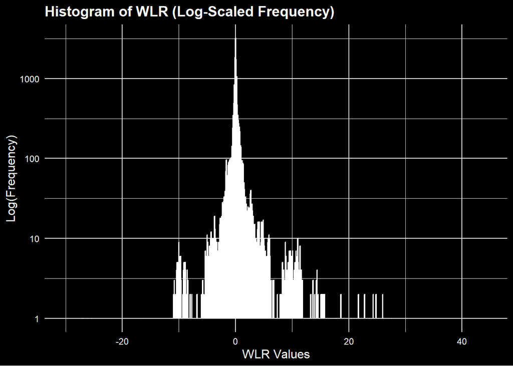

```r
# Create histogram for WLR with log-transformed frequency and x-axis starting at -30
wlr_log_plot <- ggplot(df, aes(x = WLR)) +
  geom_histogram(binwidth = 0.1, fill = "blue", color = "white", alpha = 0.7) +
  scale_y_log10() +  # Apply log transformation to y-axis
  xlim(-30, max(df$WLR, na.rm = TRUE)) +  # Ensure x-axis starts at -30
  labs(title = "Histogram of WLR (Log-Scaled Frequency)", x = "WLR Values", y = "Log(Frequency)") +
  theme_minimal() +
  theme(
    plot.title = element_text(color = "white", size = 14, face = "bold"),
    axis.title.x = element_text(color = "white", size = 12),
    axis.title.y = element_text(color = "white", size = 12),
    axis.text = element_text(color = "white"),
    panel.background = element_rect(fill = "black", color = NA), # Black background
    plot.background = element_rect(fill = "black", color = NA)   # Black background
  )

print(wlr_log_plot)
```

```r
# Save the log-transformed histogram plot
#ggsave("C:/Users/Cordio ea/Documents/WLR_Histogram_Log.png", plot = wlr_log_plot, dpi = 300, width = 8, height = 6)
```

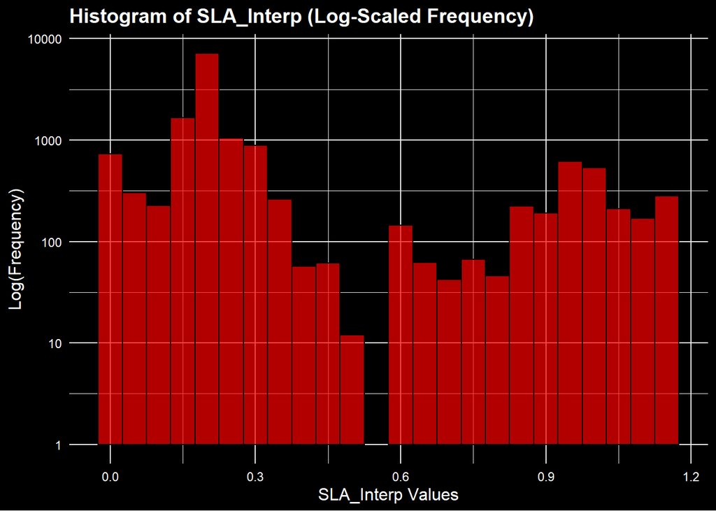

```r
# Create histogram for SLA_Interp with log y-axis
sla_plot <- ggplot(df, aes(x = SLA_Interp)) +
  geom_histogram(binwidth = 0.05, fill = "red", color = "black", alpha = 0.7) +
  scale_y_log10() +  # Logarithmic Y-axis
  labs(title = "Histogram of SLA_Interp (Log-Scaled Frequency)", x = "SLA_Interp Values", y = "Log(Frequency)") +
  theme_minimal() +
  theme(
    plot.title = element_text(color = "white", size = 14, face = "bold"),
    axis.title.x = element_text(color = "white", size = 12),
    axis.title.y = element_text(color = "white", size = 12),
    axis.text = element_text(color = "white"),
    panel.background = element_rect(fill = "black", color = NA), # Black background
    plot.background = element_rect(fill = "black", color = NA)   # Black background
  )

print(sla_plot)
```